# Diabetes Classifications Models

Final Project  
Data Science 2 with R (STAT 301-2)

Author

Chelsea Nelson

Published

March 14, 2024

**Github Repo Link**

[Final Project II Repo](https://github.com/stat301-2-2024-winter/final-project-2-chelseanelson)

## Introduction

The prediction objective at hand is to predict an individual’s diabetes diagnoses based on general health questions. This objective is a binary classification problem, as the goal is to successfully identify someone as either having diabetes or not having diabetes.

My motivation for pursuing this particular problem is because I am interested in seeing what factors of everyday life seem to play a role in the diagnosing of diabetes. This information is important as it can help zoom into the variables that play a large part in if someone has diabetes or not, as well as it helps to limit the amount of people who do have diabetes as we can successfully understand to some extent why people develop having diabetes.

I will be using the Centers for Disease Control and Prevention’s (CDC) survey data from their Behavioral Risk Factor Surveillance System (BRFSS) which is a health-related telephone survey. Although looking at multiple aspects of life through these telephone surveys, I will specifically being looking at the Diabetes Health Indicators Dataset which contains statistics and lifestyle survey information about people in general along with their diagnosis of diabetes. More information related to this dataset can be found in the References section, with both the official CDC website as well as the Kaggle page which I collected the data from.

## Data Overview & Quality

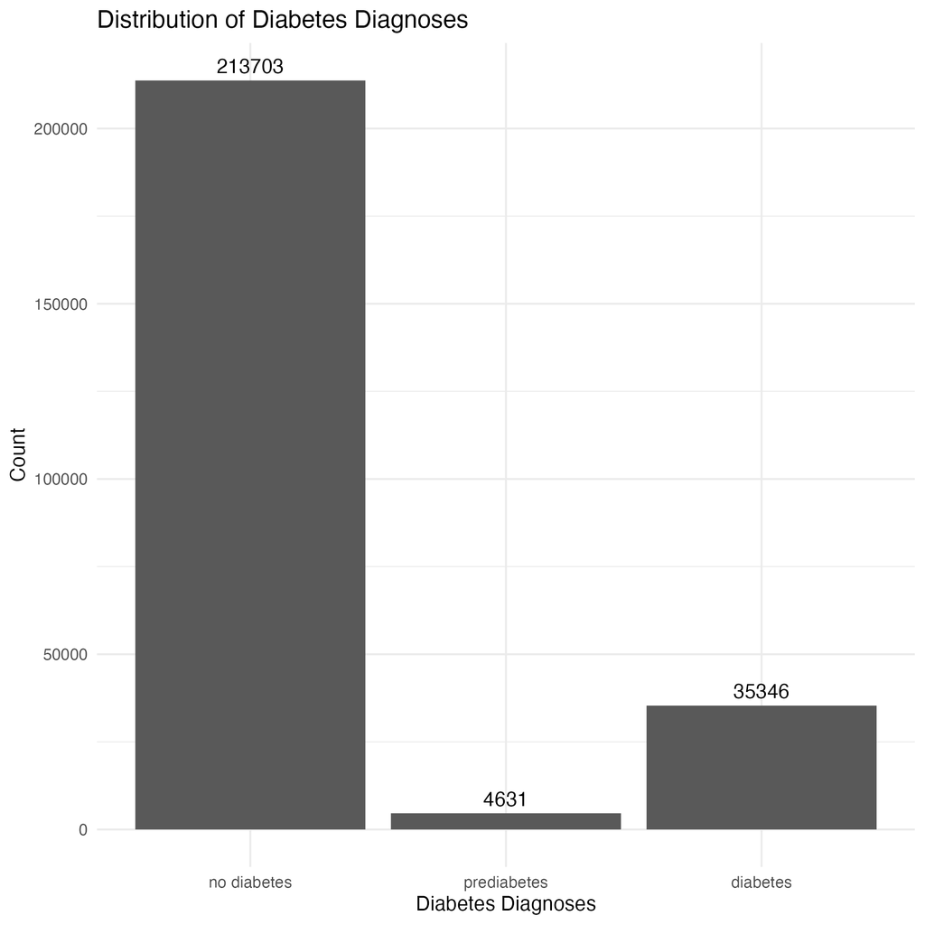

Figure 1: Diabetes Diagnosis (Original Version) - Univariate Distribution

In the original version of the dataset, there was severe class imbalance in our response variable of diabetes diagnosis. This can be shown in Figure 1. Additionally, within this original version, there were three types of diagnoses that someone could potentially receive: no diabetes, prediabetes, or diabetes.

In order to take care of this class imbalance however, I made an update to the dataset. I created my own random 50-50 split from the original larger dataset. Within this 50-50 split, I also changed my response variable from including three levels of classifications to only having two, diabetes or no diabetes. Within this change, I combined the pre-diabetes and diabetes levels into one representing now having or close to having diabetes, thus then randomly downsampling the larger no diabetes level. I decide to combine the levels in this manner as according to an ADA expert panel, up to 70% of individuals with prediabetes will eventually develop diabetes, more information supporting this claim is located in the References section.

After making these necessary changes, the response variable no longer has severe class imbalance thus being able to have my model make better predictions, as class imbalance can lead to biased models that favor the majority class, thus performing poorly on predicting the minority class. Furthermore, this then accounts for many misleading interpretations of the model performance metrics that could have arisen, allowing for me to be able to generalize the model’s predictions better.

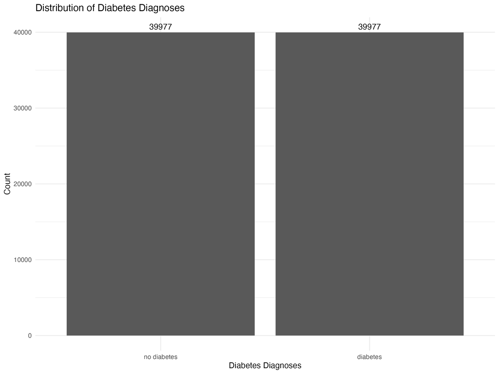

Figure 2: Diabetes Diagnosis (Updated Version) - Univariate Distribution

I have visually showcased these changes through Figure 2. We can now see that the two levels are balanced with each consisting of 39977 instances.

Additionally, it is important to point out that there are no instances of missing data within my dataset, thus I will not have to impute any variables later on to take care of its missingness.

Looking at further explorations of the predictor variables, I will focus on in this section the variables which explored bmi, high blood pressure, cholesterol levels, and the overall general health of the respondent. The rest of the EDA can be observed in Appendix I: EDA. I chose to focus mostly on these variables, as after an extensive EDA, I visualized and discovered that these variables have the strongest relationships between themselves as well as in relationship with our response variable.

### Univariate Analysis

First I will discuss the univariate distributions of each of the stated above variables of interest.

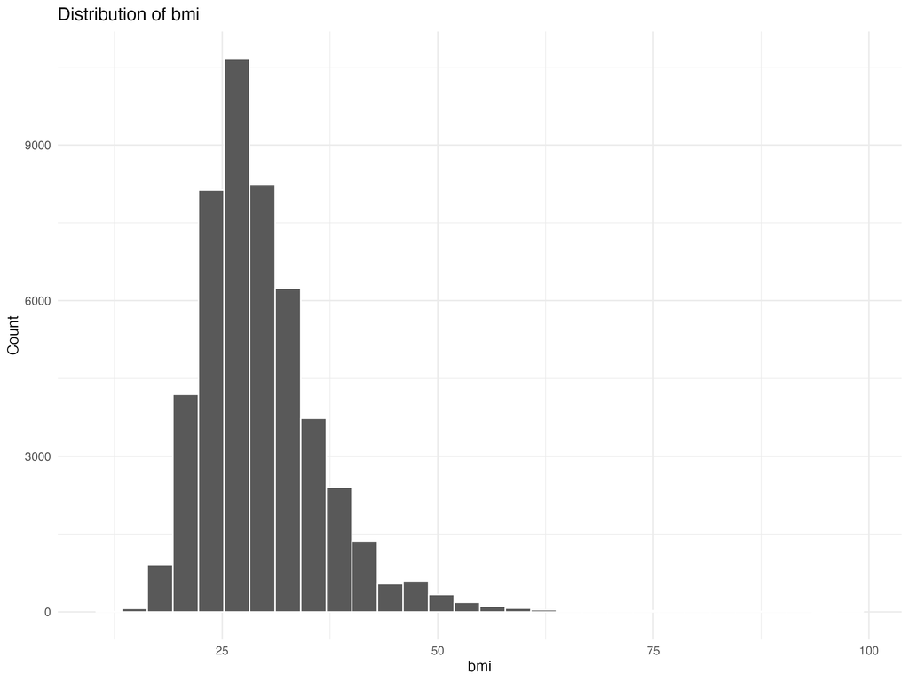

Figure 3: BMI - Univariate Distribution

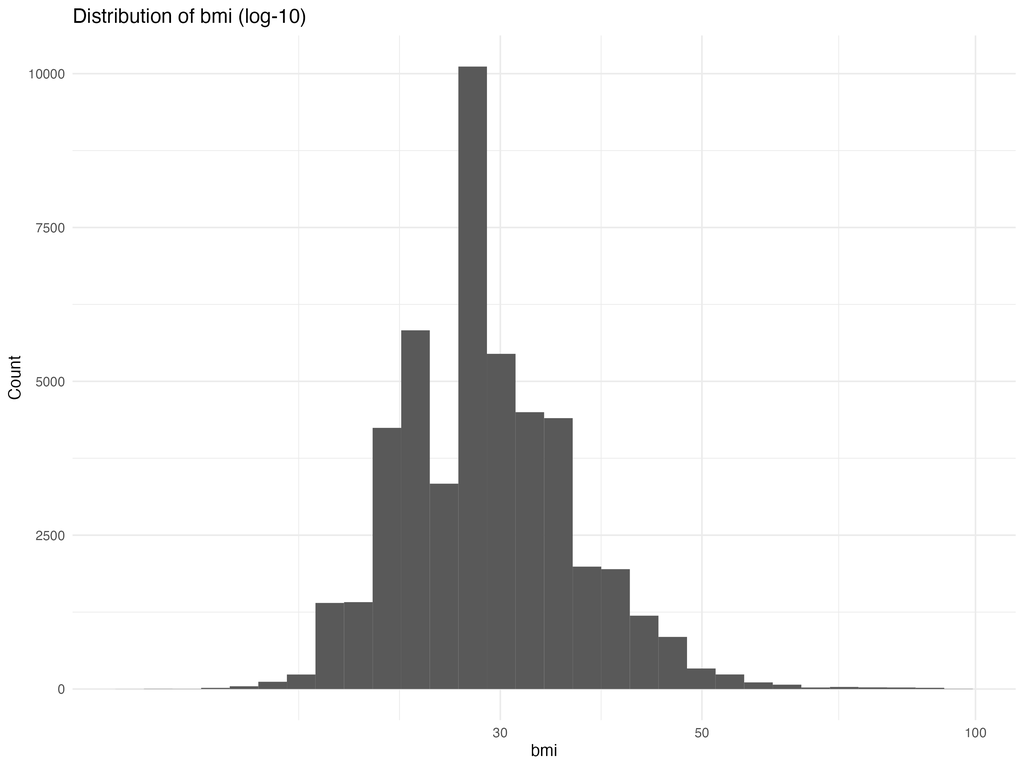

Figure 4: BMI - Univariate Distribution (log10)

Figure 4 showcases the bmi distribution of our respondents again, however now with the log10 transformation done to it. From this, we now see that the distribution is more symmetric having little to no skewedness to it as well as no outliers. Thus this confirms that by applying a log10 transformation on this variable during my pre-processing stage, I will hopefully be able to gain more diverse and substantial predictions.

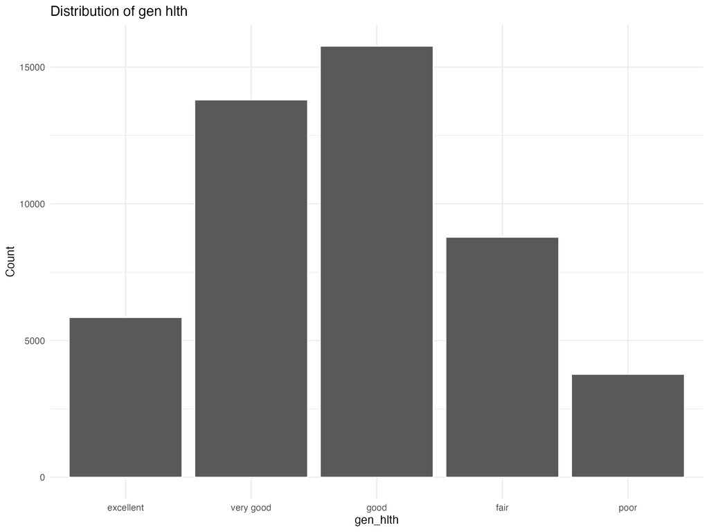

Figure 5: General Health - Univariate Distribution

Within our visualization of the general health responses (Figure 5), we see that there a lot of class imbalance. This is something that we will have to keep in mind as we go on to building the models, wanting to ensure that we recognize the existence of this as we look at the performance metrics associated with each of our model types.

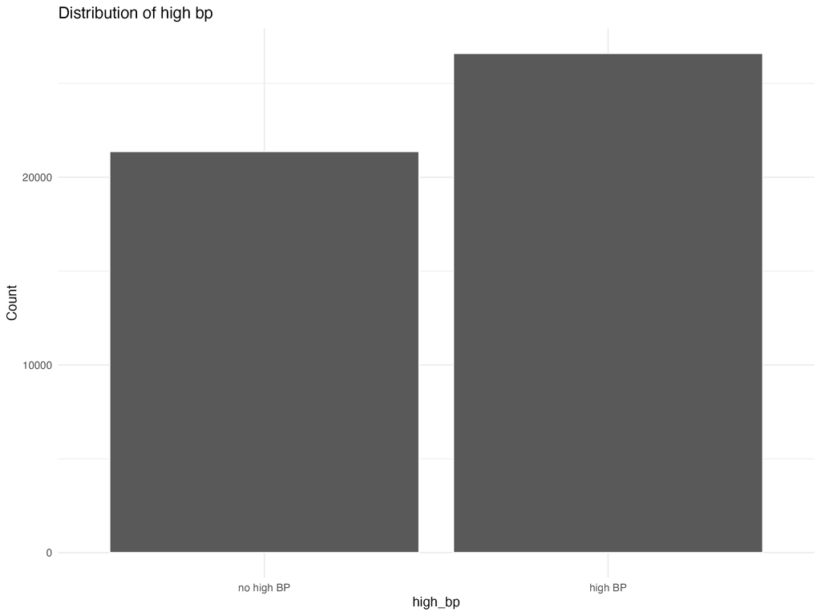

Figure 6: Blood Pressure - Univariate Distribution

Figure 6 showcases that there is an almost equal balance between our two levels within the blood pressure variable. Thus meaning that our respondents are almost equal in the amounts that have or don’t have high blood pressure. This lack of class imbalance is extremely good as it helps reduce biases in the predictions that could be made by our models.

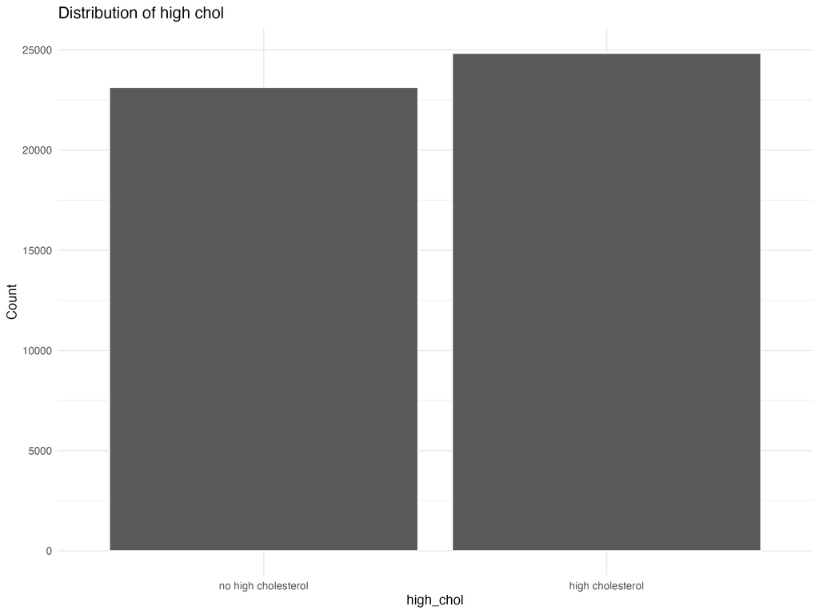

Figure 7: Cholosterol - Univariate Distribution

Similar to Figure 6, in Figure 7 we see that there is an almost equal balance between our two levels within the cholesterol variable. Thus meaning that from our respondents there is an almost equal divide of people who have and don’t have high cholesterol. As stated above, this lack of severe class imbalance will help in reducing any biases that could be obtained from our predictive variables when creating predictions from our models.

### Bivariate Analysis

Turning towards looking more at the relationship between each of these variables, overall we see that these variables are extremely related to each other, as well as with our response variable, diabetes diagnosis.

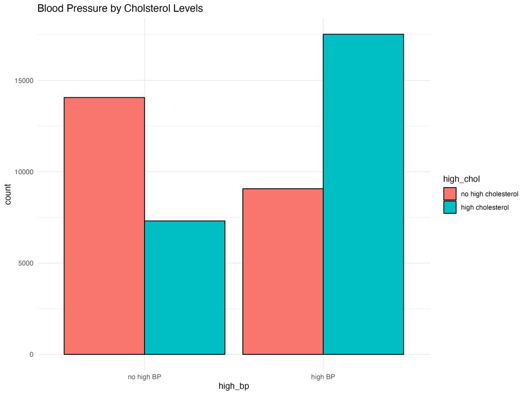

Figure 8: Blood Pressure by Cholostreol - Bivariate Distribution

Looking at Figure 8, there seems to be an extremely strong relationship between these blood pressure and cholesterol, as we see that having no high blood pressure is extremely more common when a respondent also does not have high cholesterol, and then when a respondent does have high blood pressure they are more likely to then also have high cholesterol. Seeing the strength and commonalities within this relationship, I plan to include this relationship and look more at the interactions between these two variables within my pre-processing stage for building my feature engineered recipes.

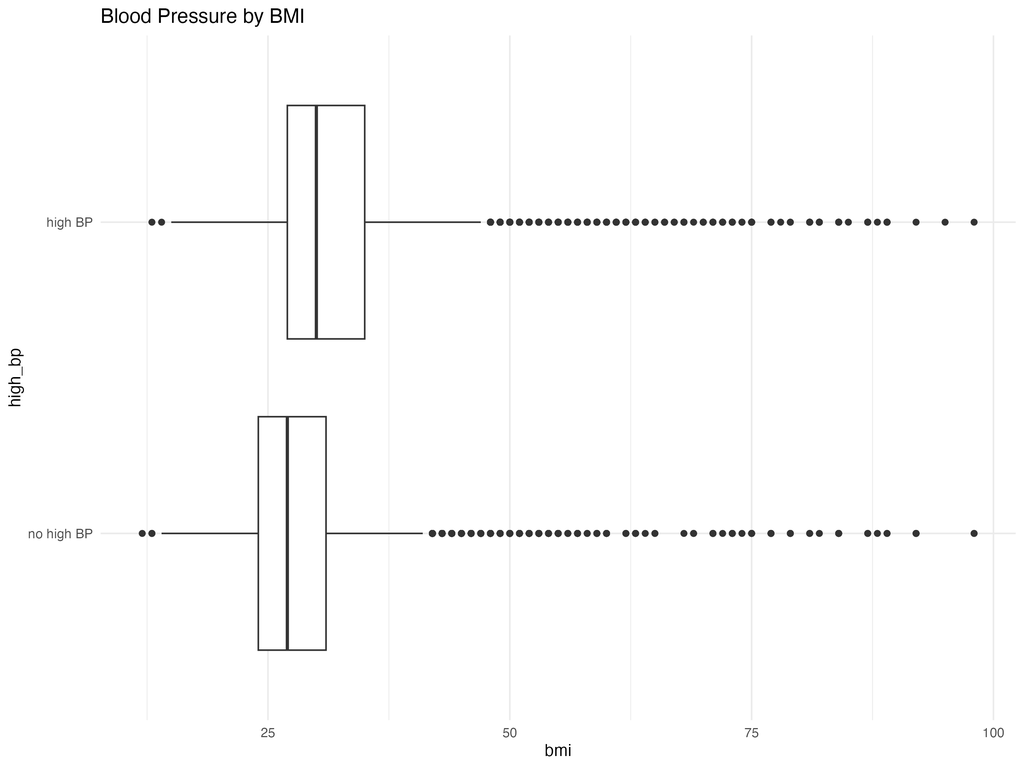

Figure 9: BMI by Blood Pressure - Bivariate Distribution

When looking at the relationships displayed in Figure 9, I find it interesting that the overall distribution of the respondents’ bmi when they don’t have high blood pressure compared to when they do is extremely similar. The only different between these distributions lies when looking at the median, and 25th and 75th quartiles. Through this we see that the average bmi for people who do have high blood pressure is higher than that of people without high blood pressure. It will be interesting to see how this relationship plays a part in the predictions created by my models.

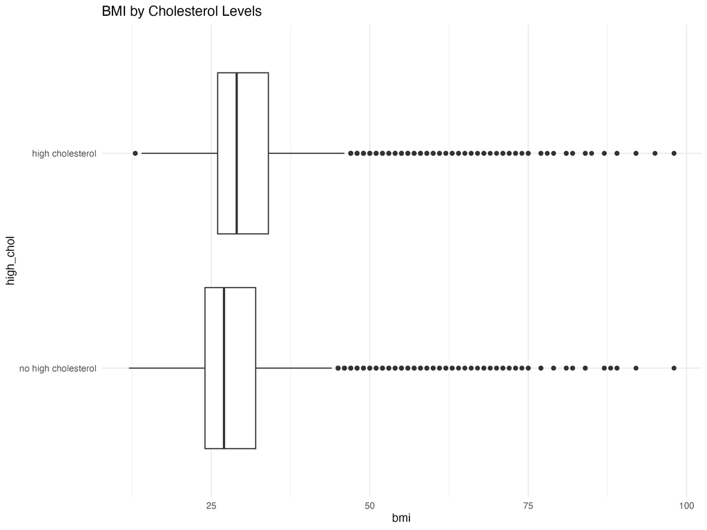

Figure 10: BMI by Cholesterol - Bivariate Distribution

Similar to Figure 9, it is interesting to see in Figure 10 that the overall distribution of the respondents’ bmi when they don’t have high cholesterol compared to when they do is extremely similar. The only difference again can be witnessed when looking at the median, and 25th and 75th quartiles of the distributions. Thus form this information, we see that the average bmi for people who do have high cholesterol is higher than that of people without high cholesterol. The degree of this relationship will also play an interesting role in the predictions that are created by my models.

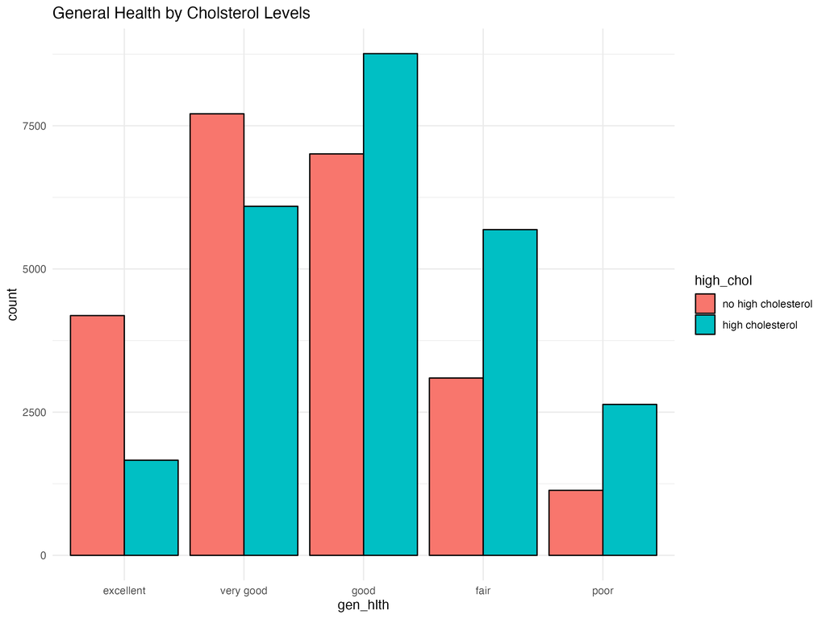

Figure 11: General Health by High Cholesterol - Bivariate Distribution

Figure 11 expresses the relationship between the degree of general health that respondents felt they have and if they have high cholesterol or not. From this relationship we can highlight that as the degree of general health get worse, we see that the amount of respondents who say that they also have high cholesterol increases as well. thus showcasing that they are connected in some manner. Although I do not do further exploration of this relationship within my pre-processing stage, I think this would be an interesting relationship to look more into their interact given the opportunity again.

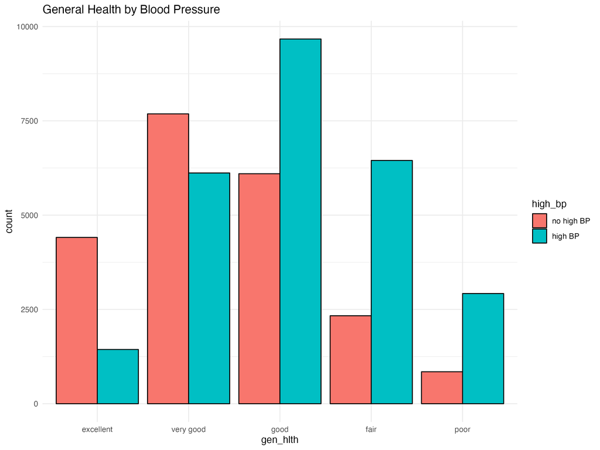

Figure 12: General Health by Blood Pressure - Bivariate Distribution

Similar to the strong relationship exhibited in Figure 11, Figure 12 also express a strong relationship between the degree of general health that respondents felt they have and if they have high blood pressure or not. From this relationship we can highlight that as the degree of general health get worse, we see that the amount of respondents who say that they also have high blood pressure increases as well. thus showcasing that they are connected in a negative manner. Although I do not do further exploration of this relationship within my pre-processing stage, I think this would be an interesting relationship to look more into their interact given the opportunity again.

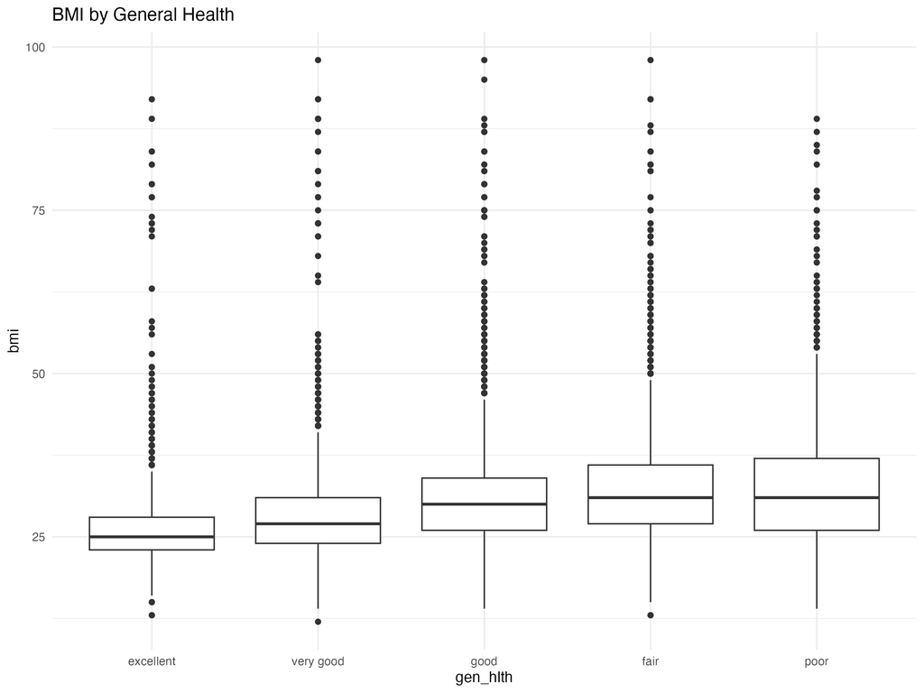

Figure 13: BMI by General Health - Bivariate Distribution

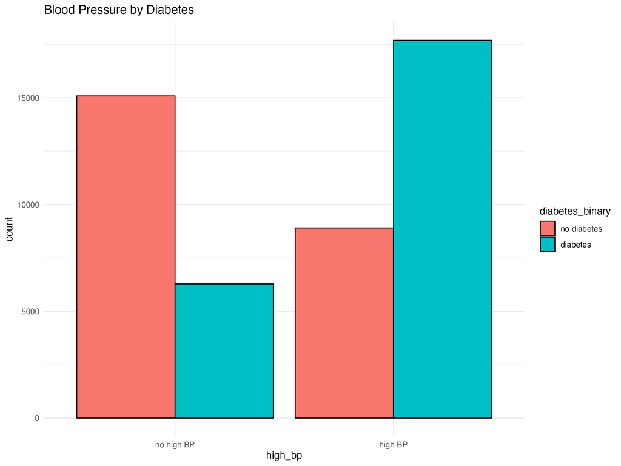

Figure 14: Blood Pressure by Diabetes - Bivariate Distribution

From Figure 14, we can see that blood pressure is extremely connected with diabetes diagnosis, as we see the trends of where someone does not have high blood pressure, they also do not have diabetes, whereas if someone does have high blood pressure, they tend to have diabetes versus not. Because of how correlated this relationship seems I will take precautions of this when doing my pre-processing work, such that it will help mitigate the power of this variable in the predictive model, both in terms of its relationship to the response variable but other predictor variables as well.

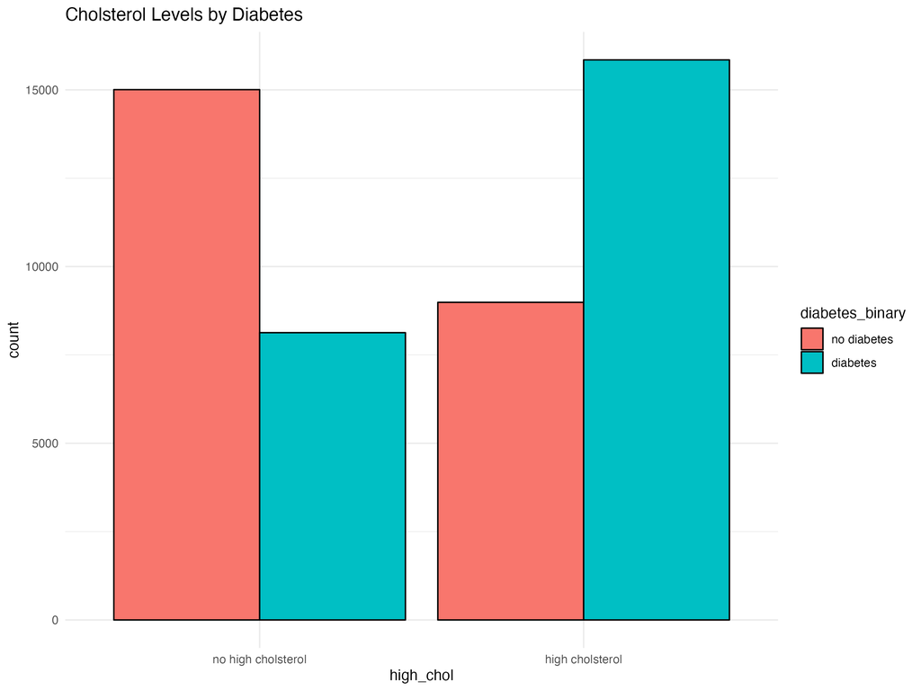

Figure 15: Cholesterol by Diabetes - Bivariate Distribution

The visualization of Figure 15 showcases to us the strong relationship that is present between cholesterol levels and diabetes diagnosis. Similar to the relationship showcased in Figure 14, we see the trend of not having high cholesterol being associated with not having diabetes, while having high cholesterol is more associated with having diabetes. Thus, I will also work to mitigate this relationship as well as high correlations present with other predictor variables.

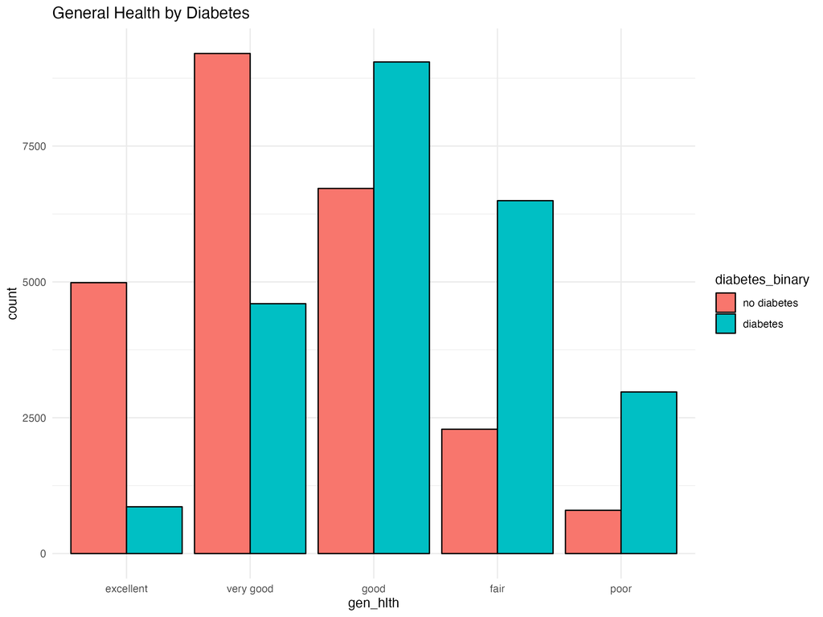

Figure 16: General Health by Diabetes - Bivariate Distribution

Figure 16 highlights the strong relationship that seems to be present between respondents’ general health assessment score and their diabetes diagnosis. We see that as the assessment scores get worse, people are more and more likely to have diabetes than not. As with the blood pressure and cholesterol variables, I will have to work around this strong relationship within my pre-processing stage, in order to mitigate any additional biases it could create for my predictions.

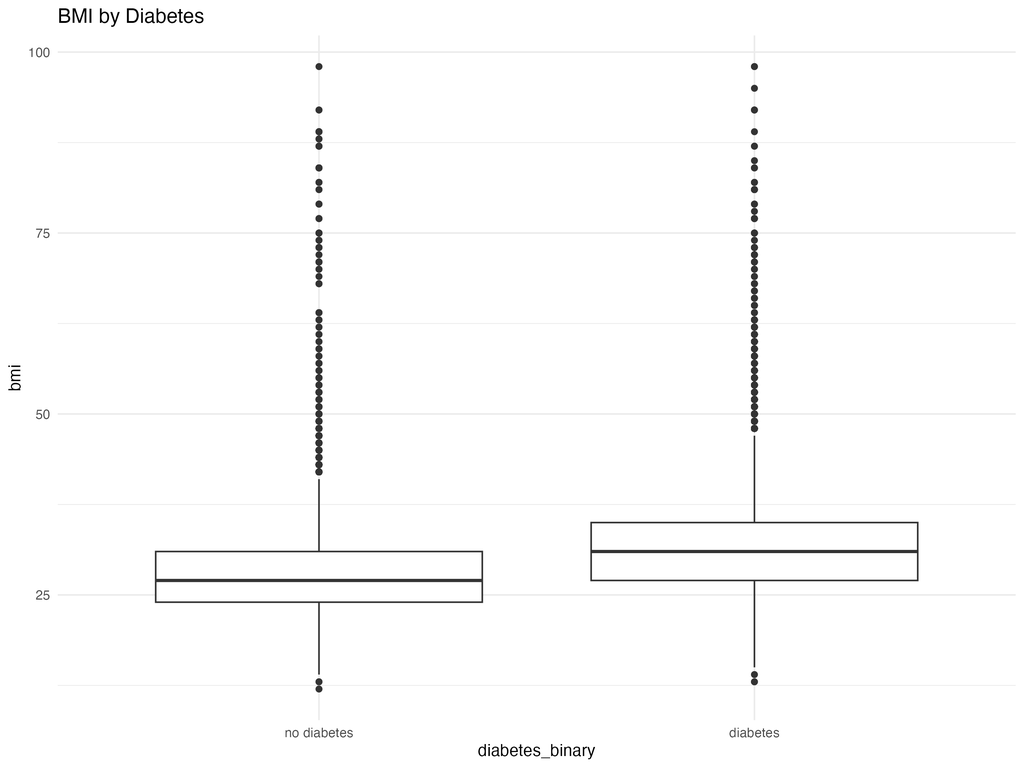

Figure 17: BMI by Diabetes - Bivariate Distribution

Lastly from Figure 17, we are able to look at the relationship between body mass index and diabetes diagnosis. There seems to be slightly strong relationship between the two of them, as we see that the median and two quartiles body mass indexes associated with each distribution increases when the person has diabetes versus when they do.

After looking at these variables as well as others that will be expressed in the Appendix I: EDA, I am ready to add on more aspects to my pre-processing stage for my second versions of my models than what I did previously when working with my kitchen sink and baseline models.

## Methods

In order to conduct and build my predictive models, I decided to split the dataset into training and testing sets using a initial 75-25 split. This is because I felt that since there are a lot of instances in my dataset, I could put more of that data into the testing set then I normally do with a regular 80-20 split. Thus this allowed for more instances to be available for evaluating the performance of the final model, potentially resulting in more reliable estimates of model performance and better generalization to unseen data.

After my initial split, I decided to conduct a cross-validation resampling technique employing 10 folds with 5 repeats to robustly estimate the models’ performance and account for potential variability in the data. By repeating the cross-validation process 5 times, I am able to obtain more reliable estimates of model performance. Additionally, with 10-fold cross-validation, the training data is divided into 10 roughly equal-sized folds. Each fold serves as both a training and testing set, allowing me to utilize a larger portion of the data for training and testing purposes. This maximizes the use of available data and provides more accurate estimates of model performance. Each model type will be fitted 50 times, allowing for good predictions to be made in terms of finding the best hyperparameters for my final model.

Additionally, as stated above it is important acknowledge that I will be conducting a binary classification prediction problem, with the primary assessment metric for the analysis will be accuracy. Accuracy provides a clear measure of the overall correctness of the model’s predictions, indicating the proportion of correctly classified instances out of the total number of instances.

In terms of the model types that I will be fitting, I have selected to use the Naive Bayes, Logistic Regression, Random Forest, Boosted Tree, $k$-Nearest Neighbors, and a Single-Layer Neural Network models for my model analysis. I have decided to use these models as they all provide me with an arrangement of models from baseline to highly advanced models to see what factors play into discovering diabetes diagnosis in the best manner.

For each model type, I have taken to tuning different parameters in order to see the different results that could be generated wanting to ultimate pick the best model possible. In terms of iteration, I used a regular grid for the tuning process of all of the models, thus where all of the combinations of the hyperparameters within the specified ranges will be evaluated exhaustively. In terms which parameters to tune and to how much, I based my decisions at least for the kitchen sink models on past examples done in class, as well as relying on the originally given ranges as well. Afterwards, my goal was to assign my tuning decisions for the feature-engineered models by looking at the best tuning parameters from the kitchen sink models. However, within this decision as well I had to weigh my the cost of tuning to a heavy extent with being time efficient in building the models. I have included specifics on how I tuned each model, within Appendix II: Tuning Models Selections

In total, I made 5 different recipes to be used with my models. Three of those models are baseline/kitchen sink recipes, whereas the last two have more feature engineering components.

Looking first at the kitchen sink recipes, I first made one specifically for my baseline Naive Bayes model. Within this recipe, I included the removal of zero variance, as well as normalized my numerical predictors. I did these features help reduce the model’s complexity and potentially avoid issues such as overfitting. These preprocessing steps help create a cleaner, more informative dataset for training the model, potentially leading to better generalization and predictive accuracy on unseen data. I did not dummy or turn numerical my categorical variables for this recipe, as the Naive Bayes model is able to work around being given straight categorical variables, with no need for change.

The second kitchen sink recipe that I created was for my parametric models, the neural network and logistic regression models. For this recipe, I included similar features such as the removal of zero variance, and the normalization of my predictors for similar reasons as mention before. Within this version, I also now included the altering of the categorical variables to being numerical through using treatment encoding, being able to to improve the performance of your models by enhancing their ability to interpret and utilize categorical information. As this was the kitchen sink/baseline recipe for my models, I decided not to add multiple different factors into its creation.

Lastly in terms of my kitchen sink recipes, I made one specifically for my tree-based models thus the boosted trees, random forest, and $k$-nearest neighbors models. This recipe includes the same features that were seen in the kitchen sink parameteric models recipe, however instead of doing treatment encoding, I did one-hot encoding when transforming my categorical variables to being numeric. I did this because type of encoding is very versatile works well when when there is no natural order among the categories.

Turning the attention to my feature engineering recipes, one was designed to again fit my parametric models, being the logistic regression and neural network models. Whereas the other was fit to work with the tree-based models, being the boosted trees, random forest, and $k$-nearest neighbors models.

When observing the former recipe, I now included the removal of variables, that I felt did not contribute to the prediction of diabetes diagnosis, those being if the respondent had healthcare or not, if they had had a cholesterol check in the past five years, and if they needed to go to the doctor but couldn’t pay for it. Additionally, I included the a log transformation for some of my numerical variables, as when looking at their univariate distributions, they showcased a lot of skewedness. Furthermore, I wanted to control for the correlated between certain variables, thus including a feature to lessen their influence if two variables correlations was greater than 0.6. Lastly, I had two interacts features between my blood pressure and cholesterol variables, as well as one between my bmi and general health assessment variables. I did this because, these specific variables as highlighted in the Data Overview & Quality section seem to have extremely strong relationships. All of these changes are in addition to the aspects that were already apart of the kitchen sink parametric recipe. I decided to add these specific aspects as I felt they would add more complex and definition to the building of my models.

Within the latter recipe, I decided to add all of the new features mentioned in my featured engineered parameteric recipe, although not including the interaction features as tree-based models already cover for any interacts between variables that could also be affecting the model’s performance. Again, these additions are in addition to the aspects that were already apart of the kitchen sink tree-based recipe. I found these additions necessary as I felt they targeted points of interest or lack there of, in terms of helping produce the best models for predicting diabetes diagnosis.

## Model Building

As stated in the Methods sections, the primary assessment metric for the analysis will be accuracy, helping to compare models and determine which will be the final/winning model. Accuracy provides a clear measure of the overall correctness of the model’s predictions, indicating the proportion of correctly classified instances out of the total number of instances.

**Performance Comparison Table**

| wflow_id | metric | mean | std_err | n |
| --- | --- | --- | --- | --- |
| bt_1 | accuracy | 0.7494731 | 0.0007708 | 50 |
| nnet_1 | accuracy | 0.7463745 | 0.0008232 | 50 |
| nnet_2 | accuracy | 0.7446802 | 0.0007566 | 50 |
| logistic_2 | accuracy | 0.7446001 | 0.0007885 | 50 |
| bt_2 | accuracy | 0.7445400 | 0.0007219 | 50 |
| rf_1 | accuracy | 0.7438064 | 0.0007656 | 50 |
| rf_2 | accuracy | 0.7436396 | 0.0007162 | 50 |
| logisitic_1 | accuracy | 0.7431692 | 0.0008041 | 50 |
| knn_1 | accuracy | 0.7134113 | 0.0005594 | 50 |
| knn_2 | accuracy | 0.7126942 | 0.0006116 | 50 |
| nbayes | accuracy | 0.6837969 | 0.0006291 | 50 |

After looking at the best tuned hyperparameters for each of the model types, I think it would be beneficial in the future to examine and try more combinations to hopefully find and achieve even better predictions and accuracy metrics. In terms of the different model types, I have listed out what were concluded to be the best parameters for each.

Neural Network (kitchen sink): `epochs` = 257 and `hidden_units` = 7

Neural Network (feature engineering): `epochs` = 1000 and `hidden_units` = 4

$K$-Nearest Neighbors (kitchen sink): `neighbors` = 15

$K$-Nearest Neighbors (feature engineering): `neighbors` = 15

Random Forest (kitchen sink): `mtry` = 5, `trees` = 2000, and `min_n` = 40

Random Forest (feature engineering): `mtry` = 5 and `min_n` = 40

Boosted Tree (kitchen sink): `mtry` = 5, `trees` = 1240, `min_n` = 27, and `learn_rate` = 0.0158

Boosted Tree (feature engineering): `mtry` = 5, `min_n` = 40, `learn_rate` = 0.631

After removing the variables assessing if someone had healthcare, if they needed to see a doctor, but didn’t have money or not, and if someone had had a cholesterol check in the last five years or not from being predictive variables in my pre-processing feature engineered recipes, it is interesting to see that the performance of said models did not really change in performance. Thus, meaning that these variables did not really have a presence within my predictive models, however at the same time not adding biases to the models as well when they were included.

Overall, as seen in the above performance comparison table, I will be selecting the kitchen sink boosted tree model as the final model to test as it has the best performance when being assessed via our main performance metric of accuracy. Additionally, because of the small standard deviation associated with the values, we can conclude that on average, most of the different tuned models stayed around this level of accuracy. It was surprising that my kitchen sink boosted tree model performed the best has I felt that there were still some biases that played into this model, that I felt I controlled better for in my heavily feature engineered models. However, I felt more surprising on the overall rankings of the models, as I did not expect for my featured engineered logistic model to performance better than my featured engineered boosted tree, $k$-nearest neighbors models, and random forest models. Also I did not expect for both of my neural network models to perform so well in comparison to the others. This is because I have never used them before, so I was unaware going in on how they performed usually. I feel it would be interesting to go back in the future and look at these differences in more depth.

## Final Model Analysis

After fitting my winning model to the full training and then testing data, I can now assess the final model’s performance being able to see how well the model generalizes to unseen data by examining its performance metrics on the testing dataset. Thus providing an indication of how well the model is likely to perform in real-world scenarios.

| metrics | estimate |
| --- | --- |
| Accuracy | 0.7469235 |
| MCC | 0.4959570 |

**Accuracy**: This metric measures the proportion of instances in which the predicted value was correctly classified. Thus, being the ratio of correctly predicted instances to the total instances. Thus the value of 0.75 tells us that the model had an accuracy of 75% in terms of correctly classifying if someone had diabetes or not.

**MCC**: MCC is a metric that takes into account all four elements of the confusion matrix (true positives, true negatives, false positives, and false negatives). It ranges from -1 to 1, where 1 indicates perfect prediction, 0 indicates random prediction, and -1 indicates total disagreement between prediction and observation. An MCC value of approximately 0.496 for indicates a moderate level of correlation between the predicted and actual instances.

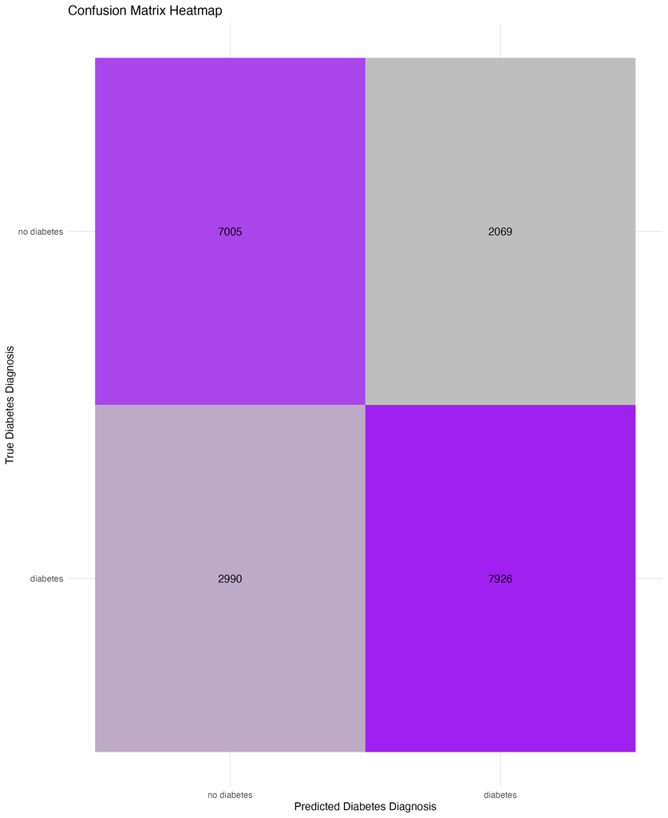

Confusion Matrix Heatmap

The Confusion Matrix tells us how the boosted tree model’s predictions aligned with the truth from the testing set. Thus from the matrix, we can see that the model currently predicted 7926 instances where the people did have diabetes, being a true positive, however having 2069 instances where it incorrectly predicted someone had diabetes when they didn’t, being a false positive. From the other side, we see that the model correctly predicted 7005 instances where the people did not have diabetes, being a true negative, however there being 2990 instances of error, as the model predicted that they did not have diabetes when they actually did, creating a false negative. This matrix seems to align well with our accuracy value of 0.75.

I think the final model is extremely good, as the accuracy value did not change terribly from the resampling training data to the test data. Additionally, this model perform a lot better than the baseline naive bayes model, which had an accuracy value of 68% in comparison to the 75% accuracy rate we achieved with our final model. I think in the future it would be beneficial however to go back and try out different pre-processing techniques to see where the true difference can be made in terms of increasing our accuracy value even more. I think that the boosted tree models reliability in terms of its scalability and flexibility in the type of data it receives helps to make it the best model out of the ones that I chose to use.

## Conclusions

In conclusion, we were able to approach our goal of predicting diabetes diagnoses based on general health questions, through utilizing various machine learning models and extensive preprocessing techniques.

Within it is important to highlight again, the initial class imbalances in our dataset, which was addressed by creating a new balanced dataset with simplified response variables. After preprocessing, which included feature engineering and addressing skewed distributions, our models were trained and evaluated.

The final model, a boosted tree model, demonstrated strong performance with an accuracy of 75% and a moderate Matthews Correlation Coefficient (MCC) of approximately 0.496 on the testing dataset.

The confusion matrix heatmap helps to illustrated the model’s predictions, aligning well with the actual values, reflecting the model’s effectiveness in correctly classifying instances of diabetes diagnoses.

Overall, the boosted tree model stood out among others, showcasing scalability, flexibility, and reliable performance. Despite some surprises in model performance rankings, the final model’s accuracy surpassed that of baseline models, indicating its potential in real-world applications.

In the future I would like to go back and look more in depth at which tuning parameters worked and provided the best results for each model, thus being able to dial more into what works and what doesn’t. As I felt that did not use the most reliable methods in terms of how I picked my tuning parameters, rather I focused more on time efficiency.

## References

1. Kaggle Diabetes Health Indicators Dataset https://www.kaggle.com/datasets/alexteboul/diabetes-health-indicators-dataset/data?select=diabetes_012_health_indicators_BRFSS2015.csv
2. CDC Behavioral Risk Factor Surveillance System https://www.cdc.gov/brfss/index.html
3. National Library of Medicine - Prediabetes: A high-risk state for developing diabetes https://www.ncbi.nlm.nih.gov/pmc/articles/PMC3891203/#:~:text=According%20to%20an%20ADA%20expert,prediabetes%20will%20eventually%20develop%20diabetes.

## Appendix

### Appendix I: EDA

Within this section I will provide the distributions of all of the other predictor variables. As well as any further bivariate distributions in which I looked at but did not express in the Data Overview & Quality section.

#### Univariate Analysis

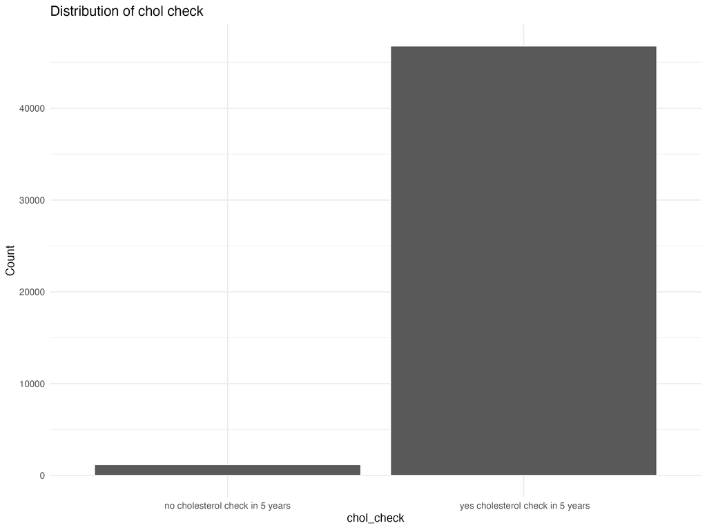

Cholesterol Check - Univariate Distribution

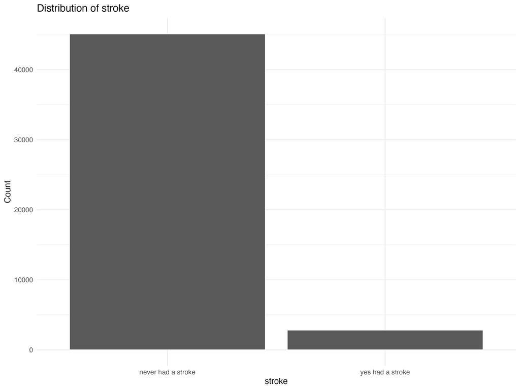

Stroke - Univariate Distribution

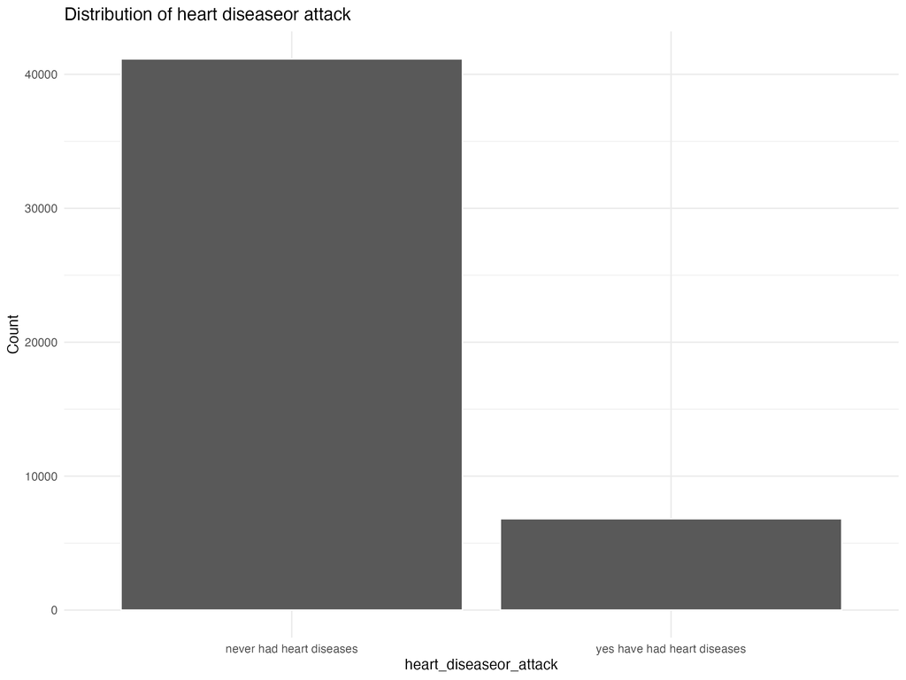

Heart Diseaseor Attack - Univariate Distribution

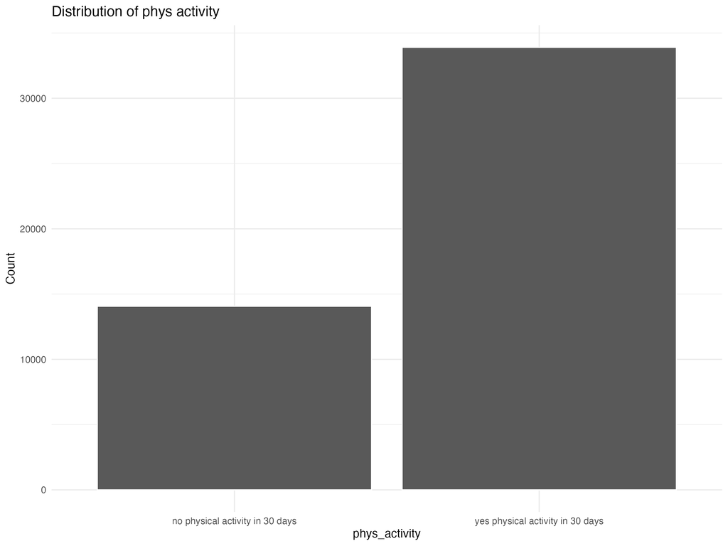

Phyisical Activity - Univariate Distribution

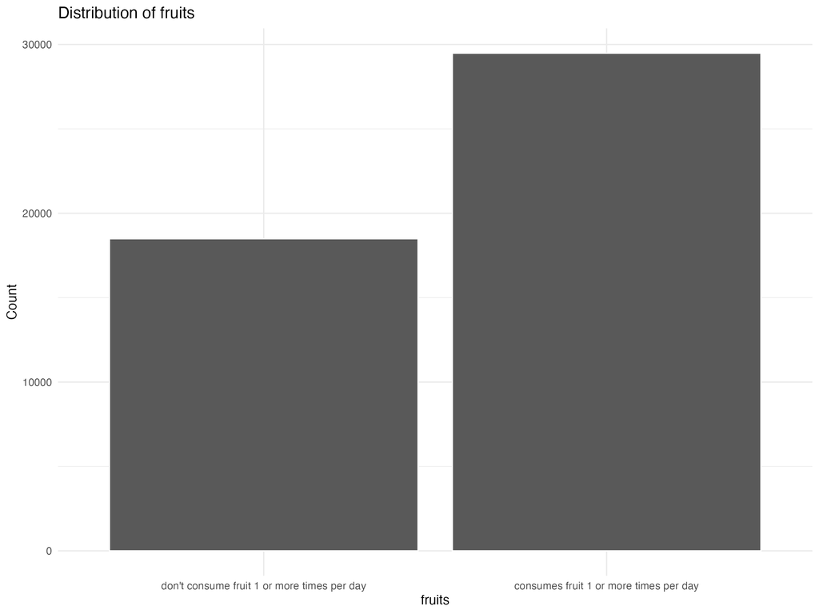

Fruits - Univariate Distribution

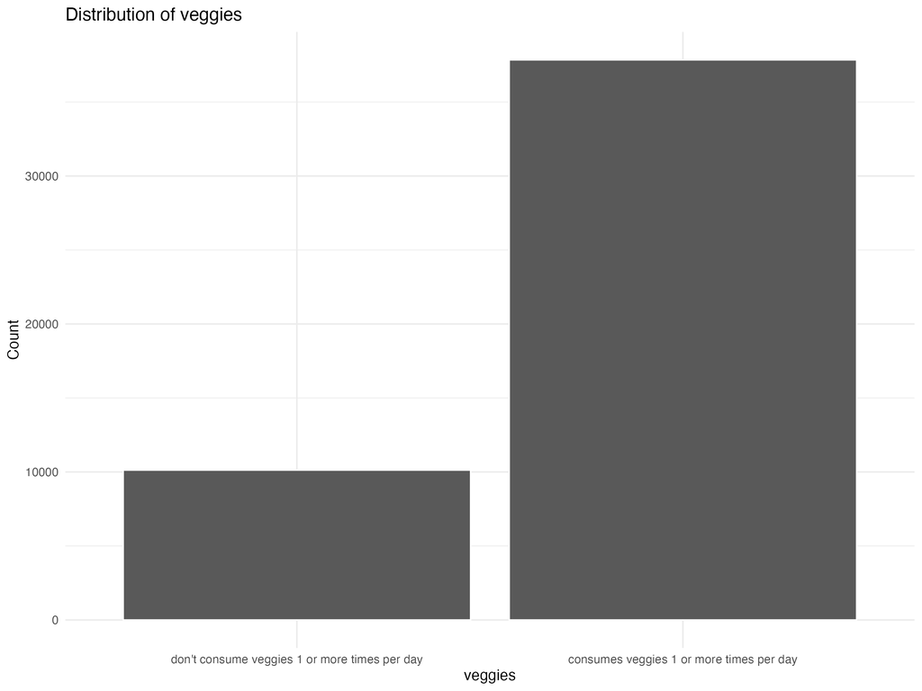

Vegetables - Univariate Distribution

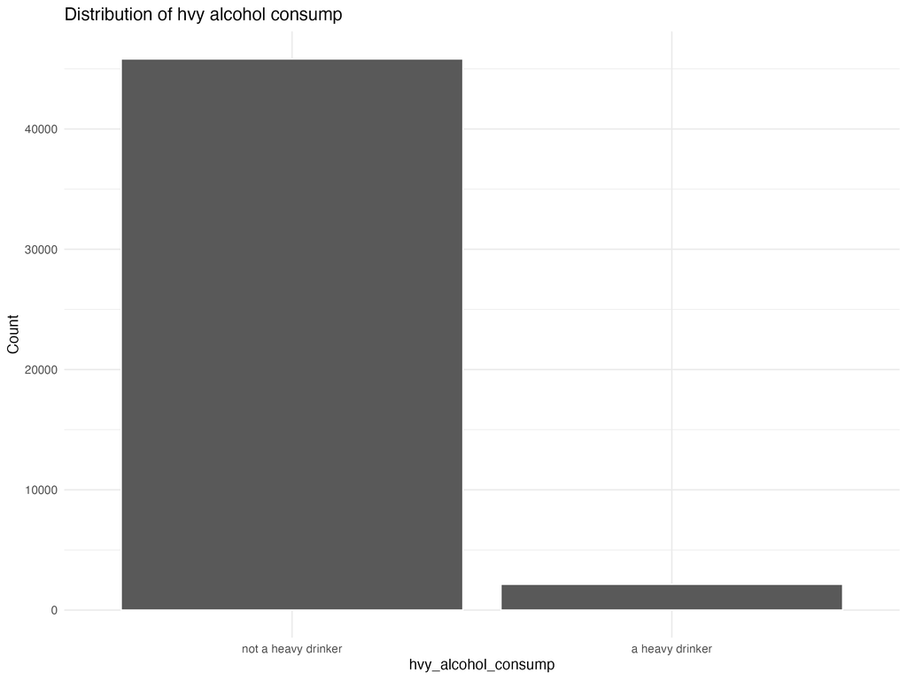

Heavy Alcohol Consumption - Univariate Distribution

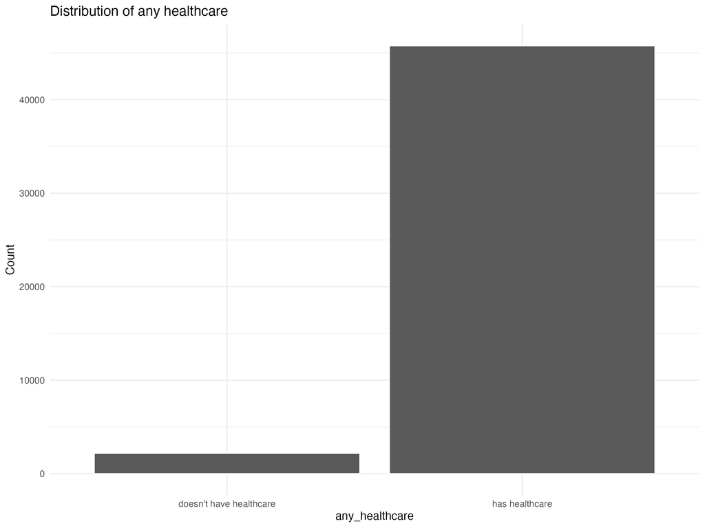

Any Healthcare - Univariate Distribution

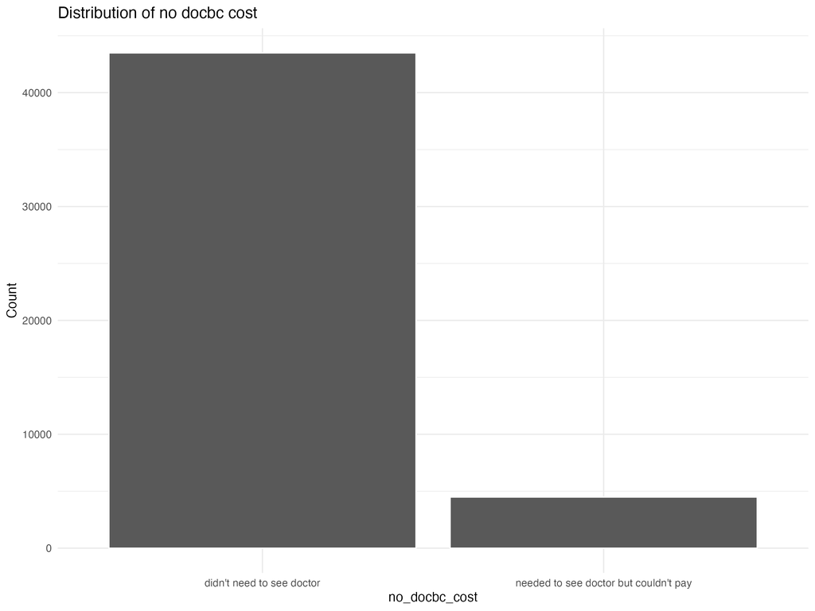

No Doctor Cause of Cost - Univariate Distribution

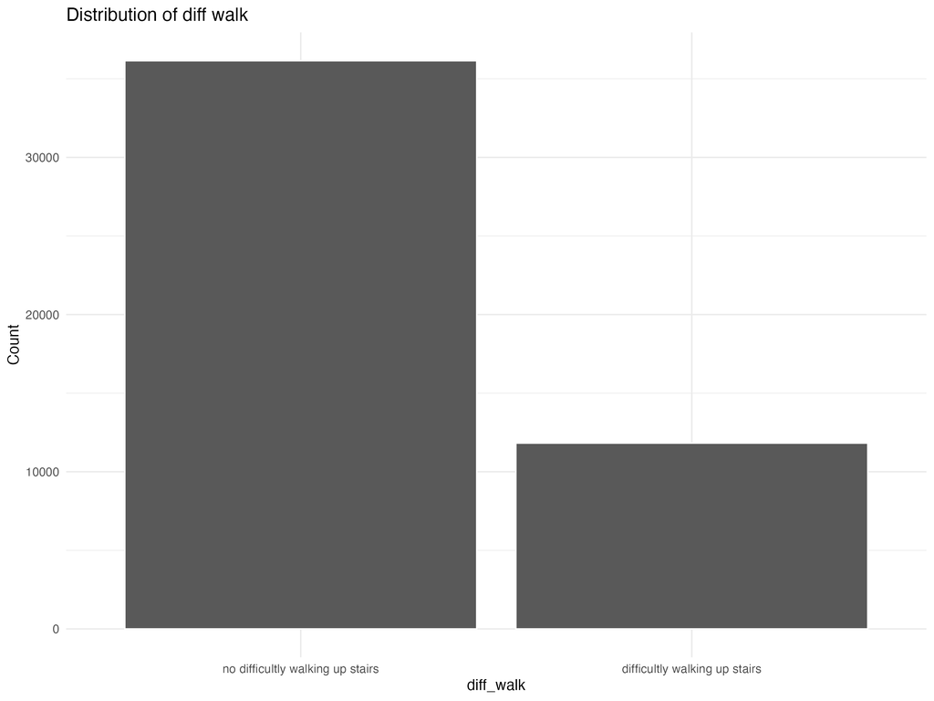

Difficulty Walking Up Stairs - Univariate Distribution

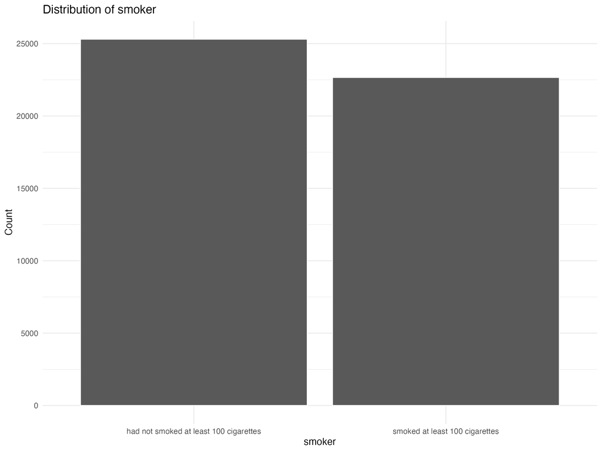

Smoker - Univariate Distribution

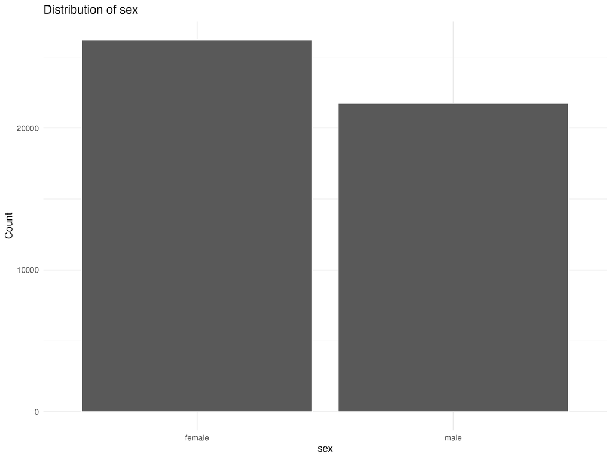

Sex - Univariate Distribution